# Part II - Ford GoBike System Data

## by Ford GoBike System Data

## Investigation Overview

> the plot I chose show the distribution of key variables, Start locations density, End locations density, and I tried to do density analysis of start, end, frequent trips

## Dataset Overview

> This data set includes information about individual rides made in a bike-sharing system covering the greater San Francisco Bay area.

## Start locations density

> Observation:
> - The starting position has the highest density at the position with x coordinates from about 37.7 to 37.8, y coordinates from about -122.5 to about -122.4.
> - The starting position has the second highest density at the position with x coordinates from about 37.8 to 37.9, y coordinates from about -122.25 to about -122.3.

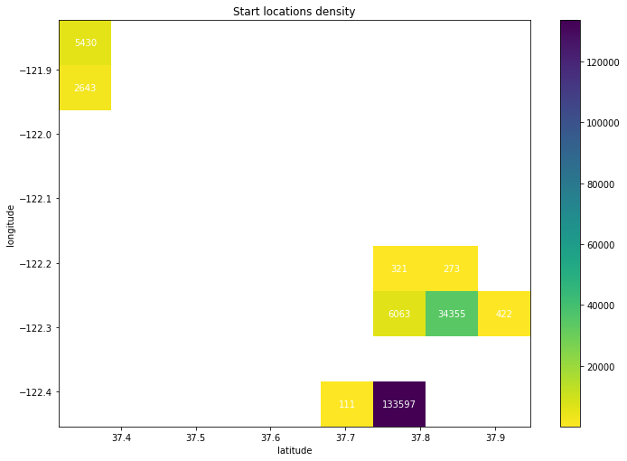

## End locations density

> Observation 2:
> - The coordinates at the end position have the same dispersion as the coordinates at the starting position
> - The starting position has the highest concentration at the position with x coordinates from about 37.7 to 37.8, y coordinates from about -122.5 to about -122.4.
> - The starting position has the second highest concentration at the position with x coordinates from about 37.8 to 37.9, y coordinates from about -122.25 to about -122.3.

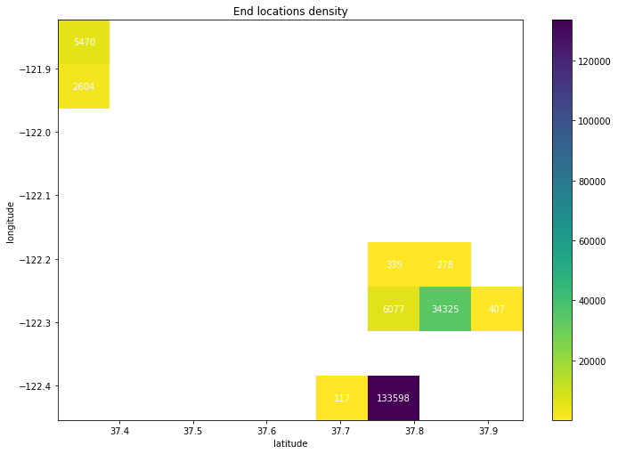

## frequent trips

> Observation :
> - Trips usually start in the range start_station_id 0 to 160 and arrive in the range end_station_id 0 to 160

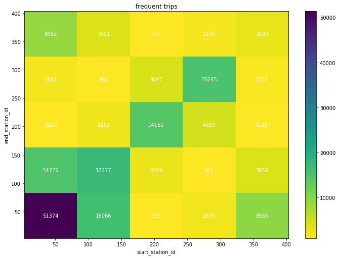